# Final Project

Peter Stirpe

May 17, 2018

1. Introduction

This is a comprehensive Exploratory Data Analysis for League of Legends, which happens to be a very popular game in esports currently.

The goal of this project is to analyze every aspect of TSM’s (pro esports team) gameplay and find their secret to winning the most games. The data comes from 8 different CSV files obtained from kaggle and are timed from 2015 to current.

In this markdown, we will first study and visualize the original data, as well as calculate many statistics for TSM based on their in game data. The reason I am choosing this experiement and TSM in particular is because TSM has been arguably the best team for a couple of years now and it is interesting to see what this team has that other teams dont. This experiment is dedicated to seeing what makes TSM so amazing that allows them to be consistenly the best team

We will also analyze TSM’s objective control and see how largly securing Dragon and Baron play into their sucess

1.1) Load in libraries and all of the data

```r
library(tidyverse)
```

```r
library(ggplot2)
library(lubridate)
bans <- read_csv("bans.csv")
structures <- read_csv("structures.csv")
columns <- read_csv("_columns.csv")
gold <- read_csv("gold.csv")
kills <- read_csv("kills.csv")
League_of_Legends <- read_csv("LeagueofLegends.csv")
match_info <- read_csv("matchinfo.csv")
monsters <- read_csv("monsters.csv")
```

1.2) File Structure and Content

Lets have an overview of the data sets using the glimpse tool

```r
glimpse(bans)
```

```
## Observations: 15,240
## Variables: 7
## $ Address <chr> "http://matchhistory.na.leagueoflegends.com/en/#match-...
## $ Team    <chr> "blueBans", "blueBans", "blueBans", "blueBans", "blueB...
## $ ban_1   <chr> "Rumble", "Kassadin", "JarvanIV", "Annie", "Irelia", "...
## $ ban_2   <chr> "Kassadin", "Sivir", "Lissandra", "Lissandra", "Panthe...
## $ ban_3   <chr> "Lissandra", "Lissandra", "Kassadin", "Kassadin", "Kas...
## $ ban_4   <chr> NA, NA, NA, NA, NA, NA, NA, NA, NA, NA, NA, NA, NA, NA...
## $ ban_5   <chr> NA, NA, NA, NA, NA, NA, NA, NA, NA, NA, NA, NA, NA, NA...
```

```r
glimpse(structures)
```

```
## Observations: 121,386
## Variables: 5
## $ Address <chr> "http://matchhistory.na.leagueoflegends.com/en/#match-...
## $ Team    <chr> "bTowers", "bTowers", "bTowers", "bTowers", "bTowers",...
## $ Time    <dbl> 27.542, 39.269, 33.583, 23.038, 16.556, 15.014, 39.376...
## $ Lane    <chr> "MID_LANE", "MID_LANE", "BOT_LANE", "TOP_LANE", "BOT_L...
## $ Type    <chr> "BASE_TURRET", "NEXUS_TURRET", "INNER_TURRET", "INNER_...
```

```r
glimpse(columns)
```

```
## Observations: 57
## Variables: 2
## $ ColumnName        <chr> "Address", "League", "Year", "Season", "Type...
## $ ColumnDescription <chr> "website address the data is scraped from \n...
```

```r
gold
```

```
## # A tibble: 99,060 x 97
##    Address     Type  min_1 min_2 min_3 min_4 min_5 min_6 min_7 min_8 min_9
##    <chr>       <chr> <int> <int> <int> <int> <int> <int> <int> <int> <int>
##  1 http://mat~ gold~     0     0   -14  - 65  -268  -431  -488 - 789 - 494
##  2 http://mat~ gold~     0     0   -26  - 18   147   237  -152    18    88
##  3 http://mat~ gold~     0     0    10  - 60    34    37   589  1064  1258
##  4 http://mat~ gold~     0     0   -15    25   228  -  6  -243   175 - 346
##  5 http://mat~ gold~    40    40    44  - 36   113   158  -121 - 191    23
##  6 http://mat~ gold~     0     0    20  - 42  - 48  - 24  -219 - 272 - 319
##  7 http://mat~ gold~     0    13   - 7     6  -353  -215  -795 - 764   369
##  8 http://mat~ gold~     0     0    26    91  -109   264   178    66 -  65
##  9 http://mat~ gold~     0   -10     0   162  -269  - 63   323   225   274
## 10 http://mat~ gold~     0     0     0    68   498   210   283   311   133
## # ... with 99,050 more rows, and 86 more variables: min_10 <int>,
## #   min_11 <int>, min_12 <int>, min_13 <int>, min_14 <int>, min_15 <int>,
## #   min_16 <int>, min_17 <int>, min_18 <int>, min_19 <int>, min_20 <int>,
## #   min_21 <int>, min_22 <int>, min_23 <int>, min_24 <int>, min_25 <int>,
## #   min_26 <int>, min_27 <int>, min_28 <int>, min_29 <int>, min_30 <int>,
## #   min_31 <int>, min_32 <int>, min_33 <int>, min_34 <int>, min_35 <int>,
## #   min_36 <int>, min_37 <int>, min_38 <int>, min_39 <int>, min_40 <int>,
## #   min_41 <int>, min_42 <int>, min_43 <int>, min_44 <int>, min_45 <int>,
## #   min_46 <int>, min_47 <int>, min_48 <int>, min_49 <int>, min_50 <int>,
## #   min_51 <int>, min_52 <int>, min_53 <int>, min_54 <int>, min_55 <int>,
## #   min_56 <int>, min_57 <int>, min_58 <int>, min_59 <int>, min_60 <int>,
## #   min_61 <int>, min_62 <int>, min_63 <int>, min_64 <int>, min_65 <int>,
## #   min_66 <int>, min_67 <int>, min_68 <int>, min_69 <chr>, min_70 <chr>,
## #   min_71 <chr>, min_72 <chr>, min_73 <chr>, min_74 <chr>, min_75 <chr>,
## #   min_76 <chr>, min_77 <chr>, min_78 <chr>, min_79 <chr>, min_80 <chr>,
## #   min_81 <chr>, min_82 <chr>, min_83 <chr>, min_84 <chr>, min_85 <chr>,
## #   min_86 <chr>, min_87 <chr>, min_88 <chr>, min_89 <chr>, min_90 <chr>,
## #   min_91 <chr>, min_92 <chr>, min_93 <chr>, min_94 <chr>, min_95 <chr>
```

```r
glimpse(kills)
```

```
## Observations: 191,069
## Variables: 11
## $ Address  <chr> "http://matchhistory.na.leagueoflegends.com/en/#match...
## $ Team     <chr> "bKills", "bKills", "bKills", "bKills", "bKills", "bK...
## $ Time     <dbl> 10.820, 16.286, 18.733, 18.880, 27.005, 27.029, 27.10...
## $ Victim   <chr> "C9 Hai", "C9 LemonNation", "C9 Hai", "C9 Meteos", "C...
## $ Killer   <chr> "TSM Bjergsen", "TSM WildTurtle", "TSM Bjergsen", "TS...
## $ Assist_1 <chr> NA, "TSM Santorin", "TSM Santorin", "TSM Santorin", "...
## $ Assist_2 <chr> NA, "TSM Bjergsen", "TSM WildTurtle", "TSM Bjergsen",...
## $ Assist_3 <chr> NA, "TSM Lustboy", "TSM Lustboy", "TSM WildTurtle", "...
## $ Assist_4 <chr> NA, NA, NA, "TSM Lustboy", "TSM Lustboy", NA, "TSM Lu...
## $ x_pos    <chr> "9229", "13908", "8281", "8522", "8902", "8559", "855...
## $ y_pos    <chr> "8469", "5960", "7889", "8895", "7643", "8491", "7924...
```

```r
glimpse(League_of_Legends)
```

```
## Observations: 7,620
## Variables: 57
## $ League           <chr> "NALCS", "NALCS", "NALCS", "NALCS", "NALCS", ...
## $ Year             <int> 2015, 2015, 2015, 2015, 2015, 2015, 2015, 201...
## $ Season           <chr> "Spring", "Spring", "Spring", "Spring", "Spri...
## $ Type             <chr> "Season", "Season", "Season", "Season", "Seas...
## $ blueTeamTag      <chr> "TSM", "CST", "WFX", "TIP", "CLG", "DIG", "CS...
## $ bResult          <int> 1, 0, 1, 0, 1, 0, 1, 1, 0, 1, 1, 1, 1, 0, 1, ...
## $ rResult          <int> 0, 1, 0, 1, 0, 1, 0, 0, 1, 0, 0, 0, 0, 1, 0, ...
## $ redTeamTag       <chr> "C9", "DIG", "GV", "TL", "T8", "TIP", "WFX", ...
## $ gamelength       <int> 40, 38, 40, 41, 35, 24, 39, 43, 41, 32, 52, 4...
## $ golddiff         <chr> "[0, 0, -14, -65, -268, -431, -488, -789, -49...
## $ goldblue         <chr> "[2415, 2415, 2711, 3887, 5068, 6171, 7412, 8...
## $ bKills           <chr> "[[10.82, 'C9 Hai', 'TSM Bjergsen', [], 9229,...
## $ bTowers          <chr> "[[27.542, 'MID_LANE', 'BASE_TURRET'], [39.26...
```

[output cut: 44 more lines]

```r
glimpse(match_info)
```

```
## Observations: 7,620
## Variables: 30
## $ League           <chr> "NALCS", "NALCS", "NALCS", "NALCS", "NALCS", ...
## $ Year             <int> 2015, 2015, 2015, 2015, 2015, 2015, 2015, 201...
## $ Season           <chr> "Spring", "Spring", "Spring", "Spring", "Spri...
## $ Type             <chr> "Season", "Season", "Season", "Season", "Seas...
## $ blueTeamTag      <chr> "TSM", "CST", "WFX", "TIP", "CLG", "DIG", "CS...
## $ bResult          <int> 1, 0, 1, 0, 1, 0, 1, 1, 0, 1, 1, 1, 1, 0, 1, ...
## $ rResult          <int> 0, 1, 0, 1, 0, 1, 0, 0, 1, 0, 0, 0, 0, 1, 0, ...
## $ redTeamTag       <chr> "C9", "DIG", "GV", "TL", "T8", "TIP", "WFX", ...
## $ gamelength       <int> 40, 38, 40, 41, 35, 24, 39, 43, 41, 32, 52, 4...
## $ blueTop          <chr> "Dyrus", "Cris", "Flaresz", "Rhux", "Benny", ...
## $ blueTopChamp     <chr> "Irelia", "Gnar", "Renekton", "Irelia", "Gnar...
## $ blueJungle       <chr> "Santorin", "Impaler", "ShorterACE", "Rush", ...
## $ blueJungleChamp  <chr> "RekSai", "Rengar", "Rengar", "JarvanIV", "Ja...
```

[output cut: 17 more lines]

```r
glimpse(monsters)
```

```
## Observations: 44,248
## Variables: 4
## $ Address <chr> "http://matchhistory.na.leagueoflegends.com/en/#match-...
## $ Team    <chr> "bDragons", "bDragons", "bDragons", "bDragons", "bDrag...
## $ Time    <dbl> 37.267, 32.545, 26.177, 19.119, 24.577, 37.867, 30.870...
## $ Type    <chr> "DRAGON", "DRAGON", "DRAGON", "DRAGON", "DRAGON", "DRA...
```

1.3) Missing Values

In this case there are a lot of missing values in some tables that correspond to bans and gold difference at a certain time. This is because some games go longer than others which causes there to be discrepencies with turning the data into a table. To handle this we will filter out games that go too long or too short based on our preferences of the data that we would like to present.

1.4) Calculate Winrate based on Red and Blue side

```r
library(ggplot2)

# Pull TSM blueside data
TSM_blueside<- select(League_of_Legends, 1:57) %>%
  filter(match_info$blueTeamTag == "TSM" & League_of_Legends$League == "NALCS" & League_of_Legends$Type == "Season" & Year != "2018")

# Pull TSM redside data
TSM_redside <- select(League_of_Legends, 1:57) %>%
  filter(League_of_Legends$redTeamTag == "TSM" & League_of_Legends$League == "NALCS" & League_of_Legends$Type == "Season" & Year != "2018")

# Had 3 extra rows so we need to delete
TSM_redside <- TSM_redside[-c(91, 92, 93), ]


# Calculate amount of blue side wins and losses
TSMB_wins <- sum(TSM_blueside$bResult == 1)
TSMB_loss <- sum(TSM_blueside$bResult == 0)
TSMB_Total_Games <- TSMB_wins + TSMB_loss

# Calculate amount of red side wins and losses
TSMR_wins <- sum(TSM_redside$rResult == 1)
TSMR_loss <- sum(TSM_redside$rResult == 0)
TSMR_Total_Games <- TSMR_wins + TSMR_loss

# Winrate for Blue side
TSMB_wr <-  TSMB_wins/TSMB_Total_Games
TSMB_wr
```

```
## [1] 0.7444444
```

```r
# Winrate for Red side
TSMR_wr <- TSMR_wins/TSMR_Total_Games
TSMR_wr
```

```
## [1] 0.6666667
```

A simple Histogram is show below showing the difference in winrates between the red and the blue side

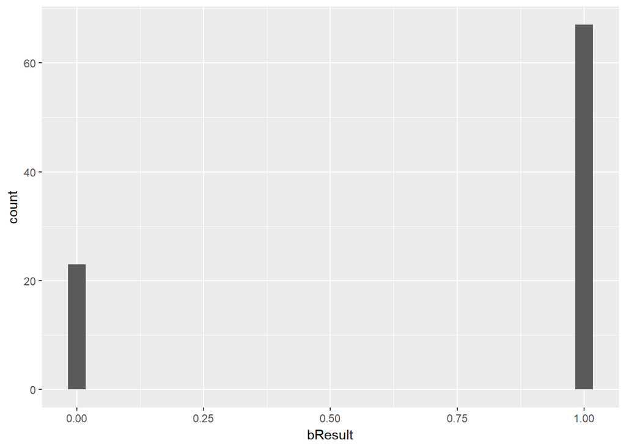

```r
# Histogram for blueside
ggplot(TSM_blueside, aes(x = bResult)) +
  geom_histogram()
```

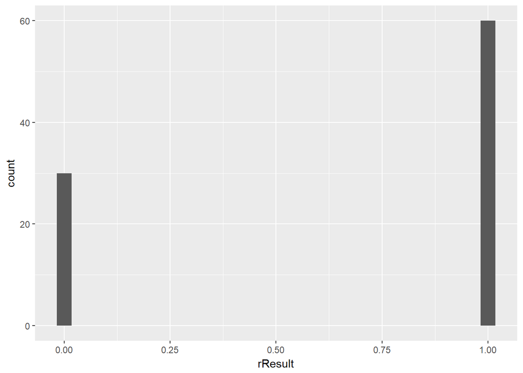

```r
# Histogram for redside
ggplot(TSM_redside, aes(x = rResult)) +
  geom_histogram()
```

2. OBJECTIVE CONTROl

Since we calculated winrate, we should go a little deeper into our analysis and see how much influence objective control has one winrate. Calculating dragon, tower, inhibitor, and baron control should help our analysis become much more specific and important.

2.1) Amount of dragons obtained on Blue and Red side

DISCLAIMER: First before I try and use the data involving dragon control, I need to tidy the data I want to use. In this block of code, I change the bDragon and rDragon column to contain the specific amount of dragons obtained in that match as an integer instead of its previous representation. ex) ([33.123, “AIR_DRAGON”]) now goes to “1” ex) ([14.234, “None”], [31.356, “None”]) now goes to “2” ect…

```r
for(i in 1:90){
  if(i < 28){
    TSM_blueside$bDragons[i] <- as.character(str_count(TSM_blueside$bDragons[i],"None"))
    TSM_redside$bDragons[i] <- as.character(str_count(TSM_redside$bDragons[i],"None"))

    TSM_blueside$rDragons[i] <- as.character(str_count(TSM_blueside$rDragons[i],"None"))
    TSM_redside$rDragons[i] <- as.character(str_count(TSM_redside$rDragons[i],"None"))
  }
  if(i >= 28){
  TSM_blueside$bDragons[i] <-as.character(str_count(TSM_blueside$bDragons[i],"DRAGON"))
  TSM_redside$bDragons[i] <-as.character(str_count(TSM_redside$bDragons[i],"DRAGON"))

  TSM_blueside$rDragons[i] <-as.character(str_count(TSM_blueside$rDragons[i],"DRAGON"))
  TSM_redside$rDragons[i] <-as.character(str_count(TSM_redside$rDragons[i],"DRAGON"))
  }
}
# Convert all rDragon and bDragon columns to numerics instead of characters
TSM_blueside$bDragons = as.numeric(TSM_blueside$bDragons)
TSM_blueside$rDragons = as.numeric(TSM_blueside$rDragons)
TSM_redside$bDragons = as.numeric(TSM_redside$bDragons)
TSM_redside$rDragons = as.numeric(TSM_redside$rDragons)
```

2.2) Total Dragons per game

In order to understand TSM’s dragon control, we should calculate the amount of dragons generally secured in each game.

I combine both TSM_bluesude and TSM_redside tables to achieve this goal.

```r
# merging both datasets together to make one for a bargraph
TSM_games <- rbind(TSM_blueside,TSM_redside)

# Add a row to get total dragons in a game
TSM_games <- mutate(TSM_games, total_drags = bDragons + rDragons)

TSM_blueside <- mutate(TSM_blueside, total_drags = bDragons + rDragons)
TSM_redside <- mutate(TSM_redside, total_drags = bDragons + rDragons)
```

It is interesting to see in this table that most games end when they have betweeen 3-5 dragons and barely any games every end when a team has either 1-2 dragons or 6-8 dragons

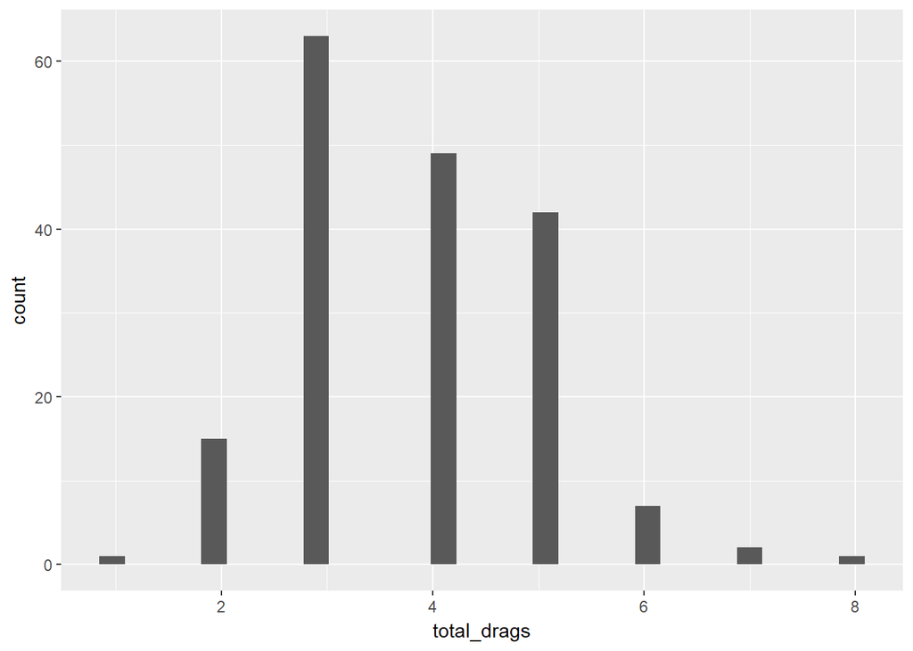

```r
ggplot(TSM_games, aes(x = total_drags)) +
  geom_histogram()
```

HOW MANY DRAGONS GET WHEN THEY ARE ON BLUESIDE

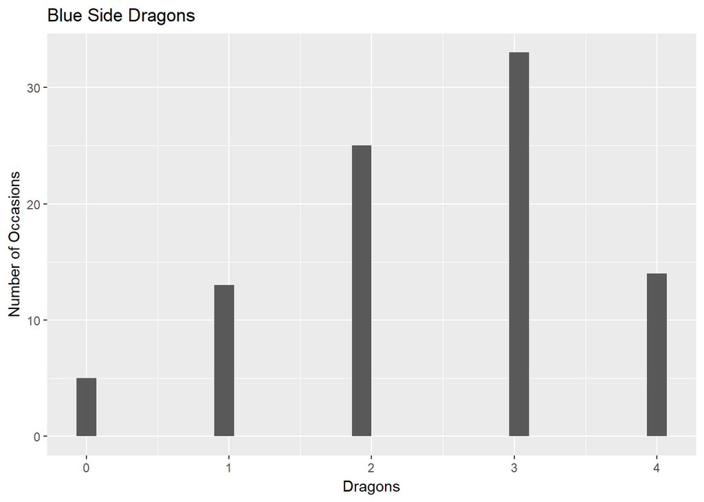

```r
ggplot(TSM_blueside, aes(x=bDragons)) +
  geom_histogram() +
  labs(title="Blue Side Dragons",
          x="Dragons", y="Number of Occasions")
```

```r
# How many dragons TSM gets on BlueSide
sum(TSM_blueside$bDragons)
```

```
## [1] 218
```

HOW MANY DRAGONS TSM GET WHEN THEY ARE ON REDSIDE

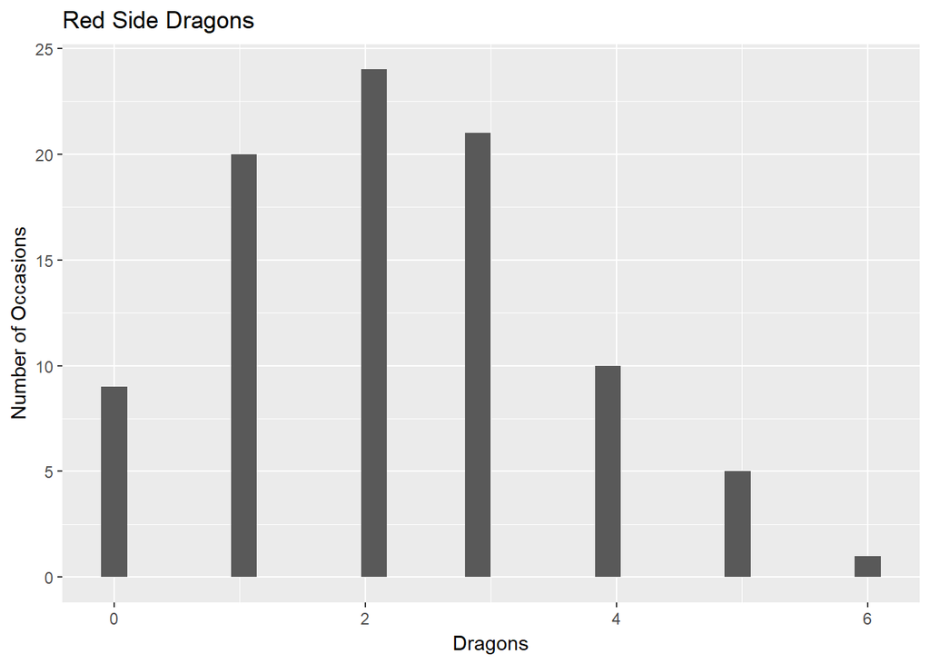

```r
ggplot(TSM_redside, aes(x = rDragons)) +
  geom_histogram() +
  labs(title="Red Side Dragons",
          x="Dragons", y="Number of Occasions")
```

```r
# How many dragons TSM gets on redside
sum(TSM_redside$rDragons)
```

```
## [1] 202
```

There is some interesting correlation in the data anaylzed here. If we look at both tables, it seems that TSM gets around the same number of dragons on average. But, on the Red side, TSM tends to sometimes obtain 5, even 6 dragons.

2.3) Winrate based on 3 dragons

We can calculate that TSM have won 90% of their games when they have only captured 3 drags a game on the red side

```r
threeDragRed <- select(TSM_redside, 1:58) %>%
            filter(rDragons == '3')
sum(threeDragRed$rResult == '1')/(sum(threeDragRed$rResult == '1') + sum(threeDragRed$rResult == '0'))
```

```
## [1] 0.9047619
```

```r
threeDragBlue <- select(TSM_blueside, 1:58) %>%
            filter(rDragons == '3')
sum(threeDragBlue$bResult == '1')/(sum(threeDragBlue$bResult == '1') + sum(threeDragBlue$bResult == '0'))
```

```
## [1] 0.5714286
```

2.4) Chances of winning based on any amount of dragons

From this graph we create a visual table which also shows the realtionship between how any dragons they secure vs how many games they win.

- The 0 1 on top of the tables stands for “loss” “win” respectively
- The 0-4 and 0-6 of the side of the tables stands for how many dragons secured each game

```r
table(TSM_blueside$bDragons,TSM_blueside$bResult)
```

```
##
##      0  1
##   0  5  0
##   1  7  6
##   2  5 20
##   3  6 27
##   4  0 14
```

```r
table(TSM_redside$rDragons, TSM_redside$rResult)
```

```
##
##      0  1
##   0  9  0
##   1  9 11
##   2  9 15
##   3  2 19
##   4  0 10
##   5  1  4
##   6  0  1
```

3. GAME LENGTH

Is this portion of the experiment, we will calculate how TSM closes out games based on the length of the game itself paired with their respective side and nothing else.

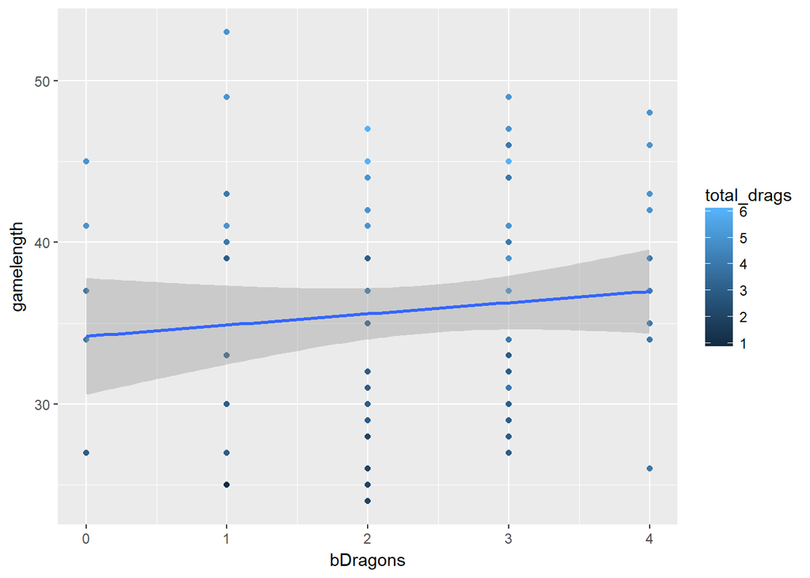

```r
ggplot(TSM_blueside, aes(x = bDragons, y = gamelength, color = total_drags)) +
  geom_point() +
  geom_smooth(method = lm)
```

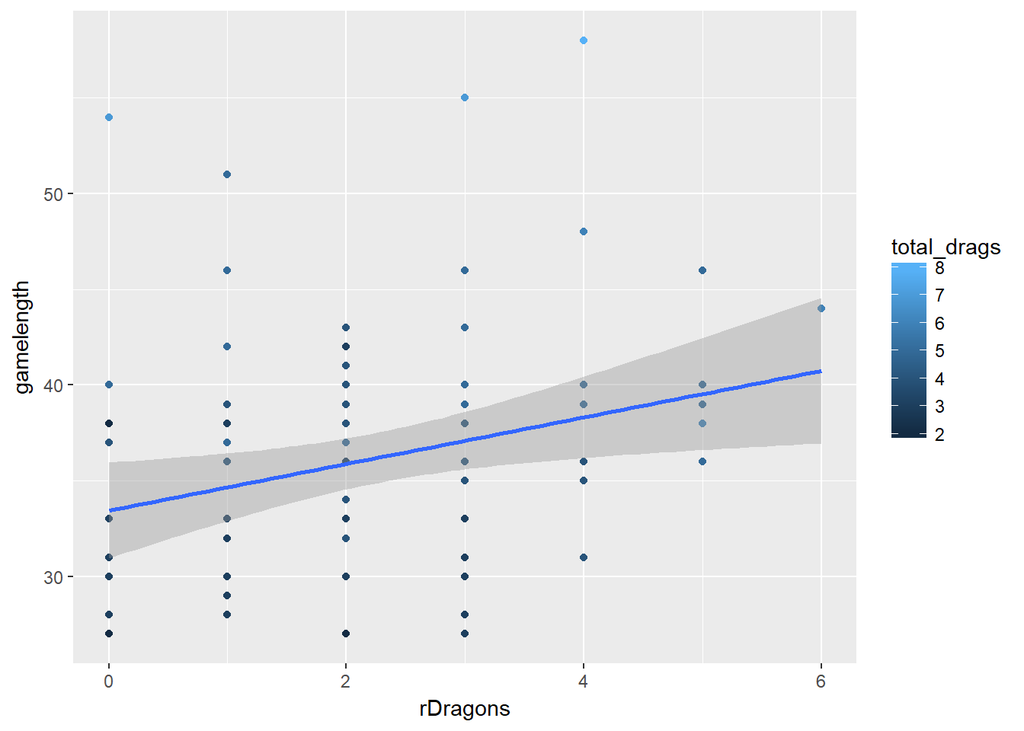

```r
ggplot(TSM_redside, aes(x = rDragons, y = gamelength, color = total_drags)) +
  geom_point() +
  geom_smooth(method = lm)
```

4. Conclusion

I hope you got something out of reading this analysis and experiment. It is clear the importance of dragon objectives based on which side that a team may be placed on. TSM, being one of the best teams just need to keep focusing on objective control in the early game which can snowball their game to a win.

# pmstirpe.github.io